# Untitled

KingMiddleton

4/5/2017

## Spatial Non-independence

At the Conard Environmental Research Area, there are 20 experimental plots with 10 burned each fall and 10 unburned. The following data are grass species richness data from 5 separate, hapazardly chosen, 10 meter^2 plots within each of these 20 experimental plots. The hypothesis to be tested is that burning increases species richness.

```r
#set.seed(54221)
set.seed(112)
mms<-c(rnorm(10, 5.5, 2),rnorm(10,6.5,2))
all.rich<-numeric(0)
for(ii in mms){
all.rich<-c(all.rich,as.integer(rnorm(5,ii,1)))
}

rich.dat<-data.frame('plot'=as.factor(rep(seq(1,20),each=5)),
                     'treatment'= rep(c('burned','unburned'),each=50),
                     'richness'=all.rich)
```

### Activity

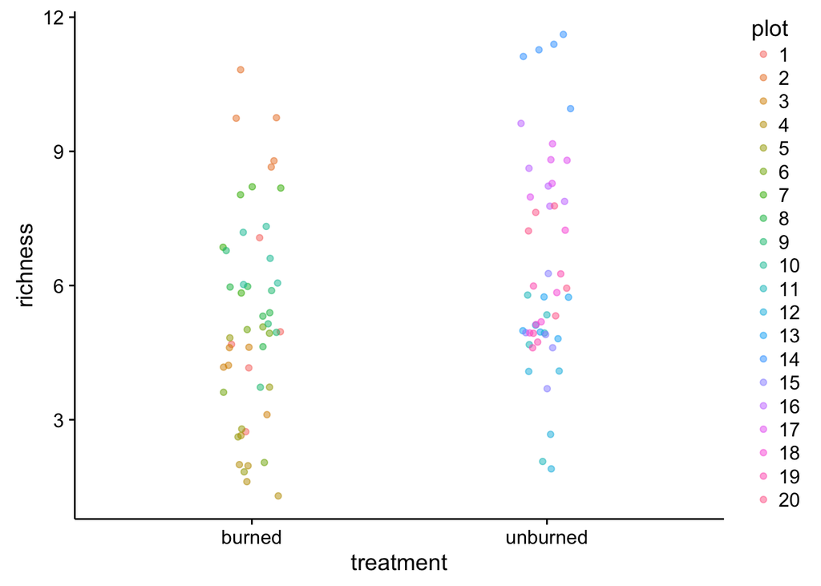

```r
ggplot(rich.dat, aes(x=treatment, y=richness, color=plot)) +
  geom_point(position = position_jitter(0.1), alpha=1/2)
```

Do you think there is a relationship between species richness and burning?

First, fit a model predicting species richness from treatment without considering plot membership. What can you conclude from the results of this model?

```r
anova(lm(richness~treatment, data=rich.dat))
```

```
## Analysis of Variance Table
##
## Response: richness
##           Df Sum Sq Mean Sq F value  Pr(>F)
## treatment  1  32.49   32.49  6.0613 0.01556 *
## Residuals 98 525.30    5.36
## ---
## Signif. codes:  0 '***' 0.001 '**' 0.01 '*' 0.05 '.' 0.1 ' ' 1
```

Now, get the mean species richness value for each plot. Fit a model predicting mean species richness from treatment. What can you conclude from this model?

```r
mean.plot<-rich.dat %>% group_by(plot,treatment) %>% summarize(meanrich=mean(richness))
anova(lm(meanrich~treatment, data=mean.plot))
```

```
## Analysis of Variance Table
##
## Response: meanrich
##           Df Sum Sq Mean Sq F value Pr(>F)
## treatment  1  6.498   6.498   1.297 0.2697
## Residuals 18 90.180   5.010
```

Use the `lme()` function to fit a model predicting richness from treatment with plot as a random effect.

```r
summary(lme(richness ~ treatment, random=~1|plot, data=rich.dat))
```

```
## Linear mixed-effects model fit by REML
##  Data: rich.dat
##        AIC      BIC   logLik
##   346.1061 356.4459 -169.053
##
## Random effects:
##  Formula: ~1 | plot
##         (Intercept)  Residual
## StdDev:    2.196361 0.9643651
##
## Fixed effects: richness ~ treatment
##                   Value Std.Error DF  t-value p-value
## (Intercept)        5.32 0.7078135 80 7.516104  0.0000
## treatmentunburned  1.14 1.0009995 18 1.138862  0.2697
##  Correlation:
##                   (Intr)
## treatmentunburned -0.707
##
## Standardized Within-Group Residuals:
##         Min          Q1         Med          Q3         Max
## -2.76767996 -0.53978614  0.05928632  0.58136355  2.26127497
##
## Number of Observations: 100
## Number of Groups: 20
```

Compare your results to the approach using the mean value. What can you conclude from this model?

These 20 plots exist in an alternating pattern going from south to north on either side of an access road. What other source of non-independence should you consider? How would you account for this factor?